# FunGraph-vignette-v0.1.0

Ang Dong

10/13/2021

# About

FunGraph can analyze the roadmap of how each locus affects phenotypic variation through its own direct effect and a complete set of indirect effects due to regulation by other loci co-existing in large-scale networks.

**For complete details on the use and execution of this protocol, please refer to [Wang et al](https://doi.org/10.1016/j.celrep.2021.109114).**

# 1. Input data

Before running FunGraph, user need to provide genotypic and phenotypic datasets, and they should be cleaned and merged to exactly the same format of the example data.

## 1.1 Phenotypic data

Phenotypic dataset contains control group and the treatment group, each with same sample id as row names and same column number to represent the times phenotypic data were measured.

```r
View(pheno)
```

|  | N1.x | N2.x | N3.x | N4.x | N5.x | N6.x | N7.x | N8.x | N9.x | N10.x |
| --- | --- | --- | --- | --- | --- | --- | --- | --- | --- | --- |
| 2 | 2.000000 | 3.000000 | 8.000000 | 12.000000 | 16.000000 | 18.000000 | 18.00000 | 21.00000 | 21.00000 | 23.00000 |
| 4 | 3.666667 | 4.333333 | 5.000000 | 5.666667 | 6.666667 | 8.333333 | 11.00000 | 13.66667 | 17.33333 | 24.33333 |
| 6 | 2.000000 | 2.666667 | 2.666667 | 2.666667 | 3.333333 | 6.666667 | 10.66667 | 17.00000 | 20.33333 | 24.33333 |
| 9 | 0.000000 | 1.000000 | 2.500000 | 5.000000 | 7.000000 | 13.000000 | 15.50000 | 23.50000 | 25.50000 | 26.00000 |
| 11 | 1.000000 | 1.000000 | 6.000000 | 19.000000 | 38.000000 | 43.000000 | 56.00000 | 74.00000 | 82.00000 | 85.00000 |
| 12 | 5.000000 | 6.000000 | 5.000000 | 6.000000 | 13.000000 | 18.000000 | 31.00000 | 41.00000 | 42.00000 | 52.00000 |

## 1.2 Genotypic data

Genotypic data have sample id as columns and SNP id as row names, and may include additional information such as the SNP position in linkage for manhattan plot.

```r
View(geno)
```

|  | Linkage | Genetic_Distances(cM) | 2 | 4 | 6 | 9 | 11 | 12 | 15 | 17 |
| --- | --- | --- | --- | --- | --- | --- | --- | --- | --- | --- |
| nn_np_9292 | lg1 | 0.00 | 0 | 1 | 9 | 0 | 0 | 1 | 1 | 0 |
| lm_ll_11315 | lg1 | 1.71 | 0 | 1 | 1 | 1 | 0 | 0 | 1 | 1 |
| lm_ll_4392 | lg1 | 2.34 | 0 | 1 | 1 | 1 | 9 | 9 | 1 | 1 |
| nn_np_8171 | lg1 | 2.55 | 0 | 1 | 9 | 0 | 0 | 1 | 9 | 0 |
| lm_ll_12452 | lg1 | 2.89 | 1 | 0 | 0 | 0 | 1 | 1 | 0 | 0 |
| lm_ll_7926 | lg1 | 3.63 | 0 | 1 | 1 | 1 | 0 | 0 | 1 | 9 |

# 2. biFunMap

Bivariate Functional mapping (biFunMap) is crucial to this model, for it excavates how specific QTLs determines the complex trait expressed in various environments. The mean vector and covariance structure should be modeled according to the design of the experiment.

## 2.1 Mean Curve

**Note:** Current `get_mu()` function use modified logistic growth curve funciton

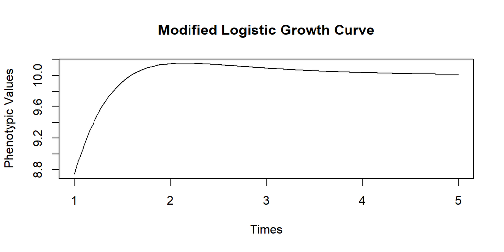

```r
plot(x = seq(1, 5, length = 100), y = get_mu(c(10, 5, 3, -2, 1), seq(1, 5, length = 100)),
    type = "l", main = "Modified Logistic Growth Curve", xlab = "Times", ylab = "Phenotypic Values")
```

For biFunMap, the `get_mu2()` is just paste two `get_mu()` function together

## 2.2 Corvariance Matrix

`get_SAD1_covmatrix()` function use modified logistic growth curve funciton

```r
get_SAD1_covmatrix(c(2, 0.5), n = 5)
```

```
##      [,1]  [,2]  [,3]  [,4]  [,5]
## [1,] 0.25  0.50  1.00  2.00  4.00
## [2,] 0.50  1.25  2.50  5.00 10.00
## [3,] 1.00  2.50  5.25 10.50 21.00
## [4,] 2.00  5.00 10.50 21.25 42.50
## [5,] 4.00 10.00 21.00 42.50 85.25
```

The corvariance matrix of biSAD1

```r
get_biSAD1(c(2, 0.5, 0.5, 2), n = 5)
```

```
##       [,1]  [,2]  [,3]  [,4]  [,5] [,6]  [,7]   [,8]    [,9]    [,10]
##  [1,] 0.25  0.50  1.00  2.00  4.00 0.00 0.000 0.0000 0.00000 0.000000
##  [2,] 0.50  1.25  2.50  5.00 10.00 0.00 0.000 0.0000 0.00000 0.000000
##  [3,] 1.00  2.50  5.25 10.50 21.00 0.00 0.000 0.0000 0.00000 0.000000
##  [4,] 2.00  5.00 10.50 21.25 42.50 0.00 0.000 0.0000 0.00000 0.000000
##  [5,] 4.00 10.00 21.00 42.50 85.25 0.00 0.000 0.0000 0.00000 0.000000
##  [6,] 0.00  0.00  0.00  0.00  0.00 4.00 2.000 1.0000 0.50000 0.250000
##  [7,] 0.00  0.00  0.00  0.00  0.00 2.00 5.000 2.5000 1.25000 0.625000
##  [8,] 0.00  0.00  0.00  0.00  0.00 1.00 2.500 5.2500 2.62500 1.312500
##  [9,] 0.00  0.00  0.00  0.00  0.00 0.50 1.250 2.6250 5.31250 2.656250
## [10,] 0.00  0.00  0.00  0.00  0.00 0.25 0.625 1.3125 2.65625 5.328125
```

## 2.3 Check initial parameters

First plot mean curve to check initial parameters is OK

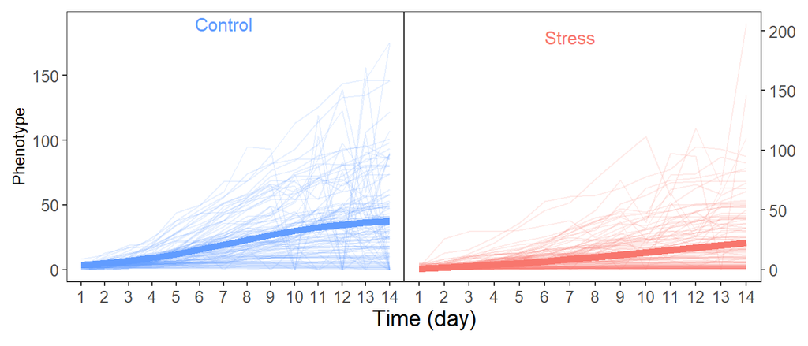

```r
get_mean_curve_plot(pheno_df = pheno, times = 1:14)
```

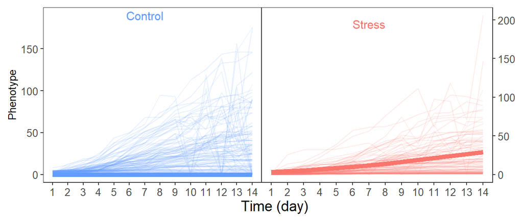

```r
# Notice wrong given inital parameters results in incorrect mean curve(blue
# line)
get_mean_curve_plot(pheno_df = pheno, times = 1:14, init_sd_par = c(2, 0.1, 2, 0.1))
```

## 2.4 biFunMap calculation

calculate LR value for a SNP

```r
# geno[,-1:-2] remove redundant information for calculation
get_LR_effect(marker = 1, geno_df = geno[, -1:-2], pheno_df = pheno, times = 1:14)
```

```
## $LR
## [1] 2.967023
##
## $genetic_effect
##  [1] 0.201284440 0.264772200 0.346411862 0.456347711 0.610781174 0.830762203
##  [7] 1.133019240 1.516061350 1.952992338 2.399895761 2.813927481 3.167246698
## [13] 3.450041283 3.665821955 0.250562724 0.176137078 0.123056444 0.084406580
## [19] 0.055011630 0.031269674 0.011047813 0.006439401 0.020841086 0.031011650
## [25] 0.035465411 0.032863884 0.022421353 0.004131180
##
## $NH0_pars
##  [1] 38.7016809 17.3447288  0.4081965 -2.6843421 10.4652100 31.1062723
##  [7]  8.9873842  0.2298382  3.0402288  0.1321409  0.8847419 13.1424409
## [13]  1.0636326  6.6143222
##
## $NH1_pars
##  [1] 42.2212696 18.9548114  0.4060741  1.0666182 11.6341456 35.8311259
##  [7] 10.4193945  0.2290326  3.7232069  0.2276818 33.7701211 17.6666255
## [13]  0.4254191 -7.0663826  8.8127371 36.7754624 10.0386477  0.2210702
## [19]  3.2022028  0.1827884  0.8758515 13.0793325  1.0659165  6.5823555
```

FunGraph already wrapped the mean curve modelling, covariance matrix modelling and likelihood ratio calculation into a function `get_biFunMap_result()`.

```r
result1 <- get_biFunMap_result(geno_df = geno[, -1:-2], pheno_df = pheno, times = 1:14)
```

## 2.5 biFunMap results visulation

Manhattan plot using calculate LR values

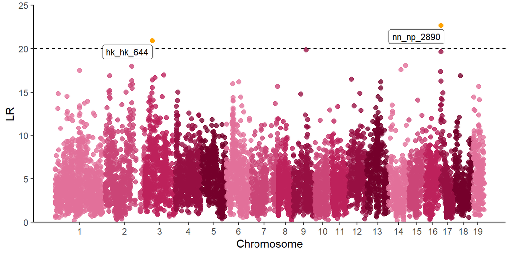

```r
get_manh_plot(geno_df = geno, LR = LR, threshold = 20)
```

**Note:** Permutation tests can be used to determine the genome-wide critical threshold(LR) by `get_permutation()`, run permutation require huge computer resoruce.

```r
# example use permutation 5 times, each permutation use first 3 SNPs
perm <- get_permutation(n = 5, geno_df = geno[1:3, -1:-2], pheno_df = pheno, times = 1:14)
## Start permutation test
## Finish permutation 1 times
## Finish permutation 2 times
## Finish permutation 3 times
## Finish permutation 4 times
## Finish permutation 5 times

threthold <- sort(do.call(c, lapply(perm, max)))
```

Choose 10 SNPs to show their genetic effect

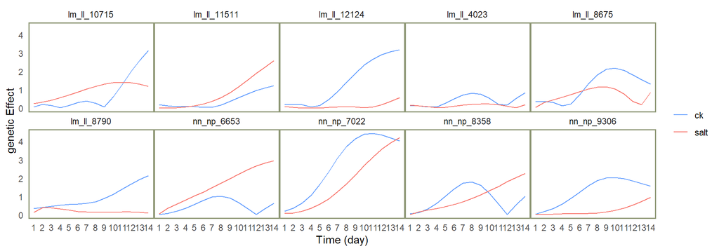

```r
get_genetic_effect_plot(genetic_effect = genetic_effect, number = 10)
## Using rownames(df_ck) as id variables
## Using rownames(df_salt) as id variables
```

## 2.6 Theory behind biFunMap

A modified logistic growth equation is a combination of the logistic growth equation and the decreasing exponential function that allows for decelerating growth during the early growth stage, where a is the asymptotic growth, b is the parameter related to initial growth, r is the relative growth rate, and c and d are two parameters that determine the pattern of decelerating growth.

$$g(t)=\frac{a}{1+b e^{-r t}}-c e^{-d t}$$

Let $\mathbf{y}_{i}=\left(y_{i}\left(t_{1}\right), \ldots, y_{i}\left(t_{T}\right)\right)$ and $\mathbf{z}_{i}=\left(z_{i}\left(t_{1}\right), \ldots, z_{i}\left(t_{T}\right)\right)$ denote the phenotypic values of a complex trait measured for the ith mapping member at time schedule $\left(t_{1}, \ldots, t_{T}\right)$ in environment $\mathrm{Y}$ and $\mathrm{Z}$, respectively. We formulate a joint likelihood for these observations, expressed as
$$L(\mathbf{y}, \mathbf{z})=\prod_{i=1}^{n} f\left(\mathbf{y}_{i}, \mathbf{z}_{i} ; \boldsymbol{\mu}_{y}, \boldsymbol{\mu}_{z}, \Sigma\right)$$
where $f(\cdot)$ is a bivariate $T$-dimensional normal distribution with mean vector $\mu=\left(\mu_{y}, \mu_{z}\right)$ and covariance matrix $\Sigma$. We assume that the time-dependent change of the trait studied can be described by a biologically meaningful mathematical function, such as growth equation, or a nonparametric smoothing function. If trait trajectories are different between two environments, parameters that describe the function of trait change should be environment specific. Because the covariance matrix contains longitudinal information, we use an autoregressive model, such as the bivariate first-order structured antedependence (biSAD(1)) model (Zhao et al., 2005), to fit the structure of the covariance, increasing the model’s parsimony. Under the null hypothesis that there is no environment-specific difference, i.e., $\mu_{y}=\mu_{z}$, we formulate a second likelihood. The calculated log-likelihood ratio (LR) can be used as a test statistic to test whether trait development is different between two environments.

The bFunMap model is built on the likelihood of phenotypic values at this SNP, expressed as
$$L_{1}(\mathbf{y}, \mathbf{z})=\prod_{j_{s}=1}^{J_{s}} \prod_{i=1}^{n_{j s}} f_{j_{s}}\left(\mathbf{y}_{i}, \mathbf{z}_{i} ; \boldsymbol{\mu}_{j_{s}}^{y}, \boldsymbol{\mu}_{j_{s}}^{z}, \Sigma\right)$$
where $f_{j s}(\cdot)$ is a $2 T$-dimensional multivariate normal distribution with mean vector $\mu_{j_{s}}^{y}=\left(\mu_{j_{s}}^{y}\left(t_{1}\right), \ldots, \mu_{j_{s}}^{y}\left(t_{T}\right)\right)$ in environment $\mathrm{X}$ and $\boldsymbol{\mu}_{j_{s}}^{z}=$ $\left(\mu_{j_{s}}^{z}\left(t_{1}\right), \ldots, \mu_{j_{s}}^{z}\left(t_{T}\right) \dagger\right)$ for environment $Y$ and covariance matrix $\Sigma$. Functional mapping models time-specific means in $\mu_{j_{s}}^{y}$ and $\mu_{j_{s}}^{z_{s}}$ by biologically meaningful mathematical equations (e.g., growth equations) that describe the developmental trajectories of the trait expressed in the two environments. To reflect environment-dependent differences, we use two sets of mathematical parameters, each related to trait development in a different environment.

After trait development-related parameters are estimated, we can calculate the genetic standard deviation of a SNP s for the trait at any time point t in environment k (k = X, Y), expressed as

$$g_{s}^{k}(t)=\sqrt{\frac{1}{n} \sum_{j_{s}=1}^{J_{s}} n_{j s}\left(\mu_{j_{s}}^{k}(t)\right)^{2}-\left(\frac{1}{n} \sum_{j_{s}=1}^{J_{s}} n_{j_{s}} \mu_{j_{s}}^{k}(t)\right)^{2}}$$
which describes the genetic effect of this SNP on trait development.

**see more about how FunMap work on [funmap2](https://github.com/wzhy2000/Funmap2).**

# 3. biFunClu

biFunClu characterize whether and how a specific locus determines the developmental trajectories of the complex trait expressed over environments.

## 3.1 initial parameters

```r
set.seed(2021)  #use same initial value

input <- get_init_par(data = genetic_effect[1:1000, ], k = 5, legendre_order = 4,
    times = 1:14)
```

View initial parameters to construct biSAD1 Covariance Matrix

```r
input$init_SAD_par
```

```
## [1] 1.06 0.25 1.15 0.18
```

Plot initial mean curve for first cluster

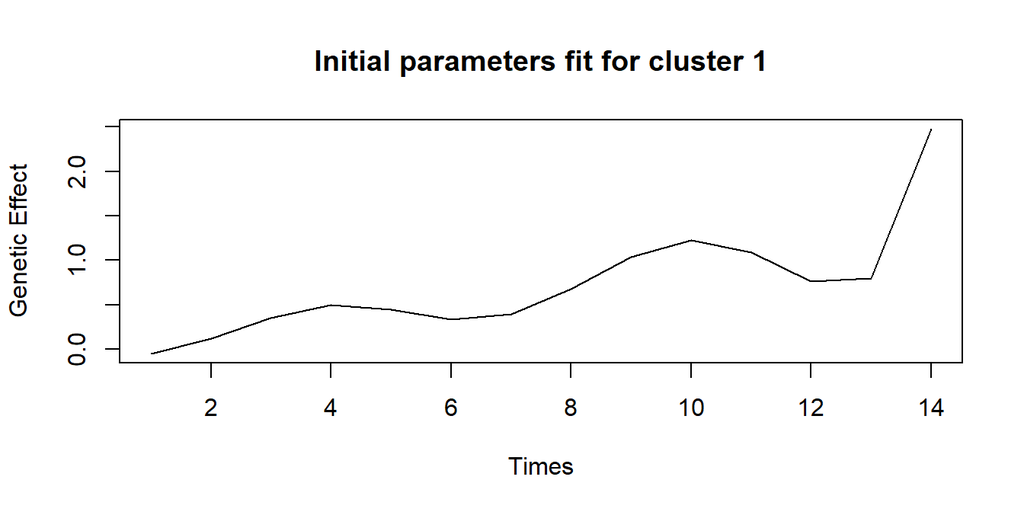

```r
plot(x = seq(1, 14), y = legendre_fit(input$init_curve_par[1, ], seq(1, 14, )), type = "l",
    main = "Initial parameters fit for cluster 1", xlab = "Times", ylab = "Genetic Effect")
```

View initial probability for every cluster

```r
input$init_pro
```

```
##
##     1     2     3     4     5
## 0.317 0.084 0.265 0.151 0.183
```

## 3.2 biFunClu calculation

```r
c1 <- get_cluster(input = input, itermax = 100)
## Start biFunClu Calculation
## Cluster_number=5 Legendre_order=4
## iter= 1 LL= -7842.927
## iter= 2 LL= -8201.417
## iter= 3 LL= -8415.089
## iter= 4 LL= -8596.408
## iter= 5 LL= -8725.103
## iter= 6 LL= -8810.075
## iter= 7 LL= -8863.696
## iter= 8 LL= -8931.289
## iter= 9 LL= -8967.508
## iter= 10 LL= -9006.885
## iter= 11 LL= -9031.633
## iter= 12 LL= -9055.059
## iter= 13 LL= -9069.032
## iter= 14 LL= -9081.922
## iter= 15 LL= -9089.843
## iter= 16 LL= -9093.78
## iter= 17 LL= -9097.559
## iter= 18 LL= -9102.341
## iter= 19 LL= -9107.377
## iter= 20 LL= -9120.011
## iter= 21 LL= -9124.702
## iter= 22 LL= -9127.728
## iter= 23 LL= -9131.037
## iter= 24 LL= -9133.609
## iter= 25 LL= -9136.067
## iter= 26 LL= -9137.597
## iter= 27 LL= -9138.914
## iter= 28 LL= -9139.122
## Finish biFunClu Calculationcluster result data written
```

## 3.3 biFunClu visulation

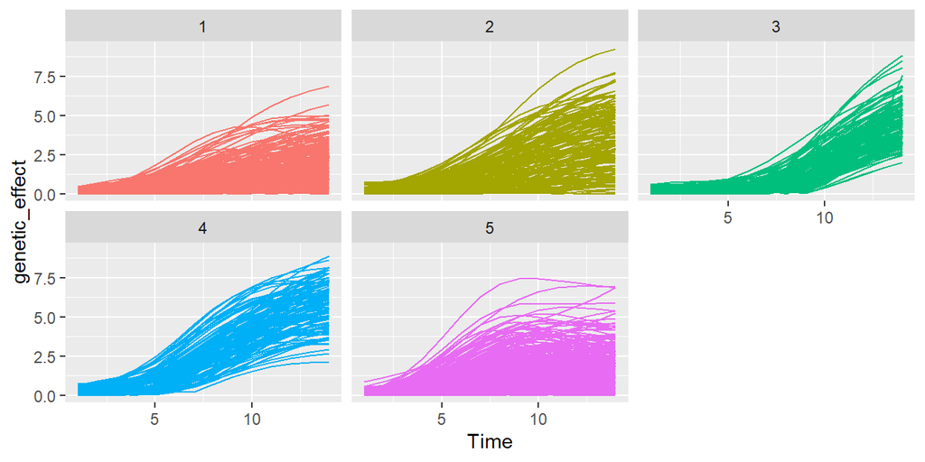

```r
get_cluster_base_plot(c1$clustered_data[[1]])
```

## 3.4 BIC

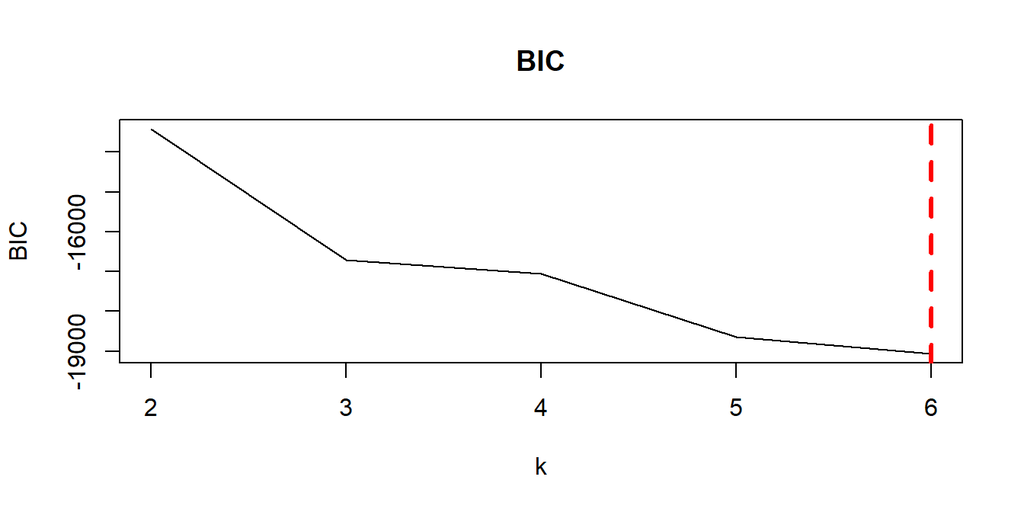

```r
set.seed(2021)

BIC <- get_BIC(data = genetic_effect[1:1000, ], order = 4, times = 1:14, rep = 3,
    min_cluster = 2, max_cluster = 6, itermax = 10)

plot(x = BIC$k, y = BIC$BIC, type = "l", main = "BIC", xlab = "k", ylab = "BIC")
abline(v = BIC$k[which.min(BIC$BIC)], col = "red", lwd = 3, lty = 2)
```

## 3.5 Theory behind biFunClu

To reflect the time-varying pattern of genetic effects, we implement bivariate functional clustering (biFunClu) (Wang et al., 2012 ) to divide all $S$ SNPs into different modules according to how they affect trait development in environment $Y$ and $Z$, described by $\mathbf{g}_{s}^{y}=$ $\left(g_{s}^{y}\left(t_{1}\right), \ldots, g_{s}^{y}\left(t_{T}\right)\right)$ and $\mathbf{g}_{s}^{z}=\left(g_{s}^{z}\left(t_{1}\right), \ldots, g_{s}^{z}\left(t_{T}\right)\right)$, respectively. BFunClu is formulated on the basis of a mixture-based likelihood model, expressed as
$$L_{2}\left(\mathbf{g}_{y}, \mathbf{g}_{z}\right)=\prod_{s=1}^{S} \sum_{l=1}^{L}\left[\pi_{i} f_{l}\left(\mathbf{g}_{s}^{y}, \mathbf{g}_{s}^{z} ; \mathbf{u}_{t}^{y}, \mathbf{u}_{i}^{z}, \Sigma_{g}\right)\right]$$
where $L$ is the number of modules, $\pi_{/}$is a prior probability representing the proportion of module $I$, and $f_{l}(\cdot)$ is the $2 T$-dimensional multivariate normal distribution with mean vector $\mathbf{u}_{1}^{y}=\left(u_{l}^{y}\left(t_{1}\right), \ldots, u_{l}^{y}\left(t_{T}\right)\right)$ for environment $\mathrm{X}$ and $\mathbf{u}_{1}^{z}=\left(u_{l}^{z}\left(t_{1}\right), \ldots, u_{l}^{z}\left(t_{T}\right)\right)$ for environment $Y$ and covariance matrix $\Sigma_{g}$. We implement a LOP-based nonparametric model to fit the structure of $\mathbf{u}_{l}^{y}$ and $\mathbf{u}_{1}^{z}$ and $\mathrm{bSAD}(1)$ to fit the structure of $\Sigma_{g}$.

We develop a hybrid of the EM and simplex algorithms to maximize the likelihood (6). An optimal number of mixture components (i.e., modules) is determined according to $\mathrm{BlC}$. The module (I) to which a specific SNP s belongs can be determined on the basis of the estimate of the posterior probability, expressed as
$$\Pi_{/ s}=\frac{\pi_{l} f_{l}\left(\mathbf{g}_{s}^{y}, \mathbf{g}_{s}^{z} ; \mathbf{u}_{1}^{y}, \mathbf{u}_{1}^{z}, \Sigma_{g}\right)}{\sum_{\prime^{\prime}}^{L} \pi_{\mu} f_{\mu}\left(\mathbf{g}_{s}^{y}, \mathbf{g}_{s}^{z} ; \mathbf{u}_{\mu}^{y}, \mathbf{u}_{\mu}^{z}, \Sigma_{g}\right)}$$

A SNP is assigned to a module if the posterior probability of this SNP $\left(\Pi_{/ \mid s}\right)$ within this module is larger than those in any other modules.

**see more about how FunClu work on [Kim et al](https://www.genetics.org/content/genetics/180/2/821.full.pdf).**

# 4.LASSO-based variable selection

FunGraph implements a LASSO-based procedure to choose a small set of the most significant genes that links with a given gene across time points. `get_interaction()`return a compound list contain the target Module/SNP name, the most relevant Modules/SNPs names and the coefficients.

## 4.1 For Modules

```r
module_data <- get_module_data(data_par = c1$curve_par, times = 1:14)

# select ck data for variable selection
get_interaction(data = module_data[[1]], col = 1)
## [[1]]
## [1] "Module1"
##
## [[2]]
## [1] "Module2" "Module3" "Module5"
##
## [[3]]
## [1] 0.34773750 0.01375537 0.28462559
```

## 4.2 For SNPs

```r
# alternatively, use a cluster data(ck) for variable selection
get_interaction(data = c1$clustered_data[[1]][, -ncol(c1$clustered_data[[1]])], col = 1,
    reduction = TRUE)
## [[1]]
## [1] "nn_np_9292"
##
## [[2]]
## [1] "lm_ll_2416"
##
## [[3]]
## [1] 2.981482
```

**Note:** The `reduction = TRUE` option can be `FALSE` if there are no need for dimensionality reduction (e.g. the number of SNPs with in module is almost as same as the number of modules, usually less than 100).

## 4.3 Theory behind variable selection

We study the following multiple response model:
$$Y=\mathrm{B} X+E$$
where $Y=\left(Y_{1}, \ldots, Y_{M}\right)^{\top} \in \mathrm{R}^{M}$ is the $M$-dimensional response, $X=\left(1, X_{1}, \ldots, X_{p}\right)^{\top}$ is the $(p+1)$ dimensional predictor, $E=\left(\varepsilon_{1}, \ldots, \varepsilon_{M}\right)^{\top} \in R^{M}$ is the $M$-dimensional random error, and $B$ is a coefficient and an $M \times(p+1)$ matrix.

In the first stage, To guarantee that the screened submodel size is under the sample size but still large enough to make a statistical inference, we followed **[Fan and Lv](https://www.genetics.org/content/genetics/180/2/821.full.pdf).** when choosing d using the hard threshold d = n/log(n).

In the second stage, the final sparse model is recovered from the screened submodel obtained in the first stage. For this multiple response model, we use the group version of the penalized regression techniques in this stage. More specifically, we consider the following minimization problem:
$$\widehat{\mathbf{B}}_{\lambda}=\operatorname{argmin}_{\mathbf{B} \in \mathcal{R}^{n \times(d+1)}}\left\{\sum_{t=1}^{M} \sum_{i=1}^{n}\left(y_{i t}-x_{i}^{\mathrm{T}} \beta_{t}\right)^{2}+n \sum_{j=1}^{d+1} p_{\lambda}\left(\left\|b_{j}\right\|\right\}\right.$$
where $p_{\lambda}(\cdot)$ is a penalty function and $\lambda$ is the tuning parameter.

**see more about how LASSO-based variable selection work on [Liu et al](https://onlinelibrary.wiley.com/doi/full/10.1111/tpj.13777).**

# 5. ODE solving

A system of nLV ODEs are formulated according to evolutionary game theory, with the independent part describing the inner genetic effect of SNP i and the dependent part describing the influential genetic effect of other SNPs. Thereafter, the genetic network could be reconstructed through the decomposition of net genetic effect of each SNP.

## 5.1 Genetic network reconstructed for modules

```r
# Prepare genetic effect dataset for modules
module_data <- get_module_data(data_par = c1$curve_par, times = 1:14)
# Solve ODE between modules
module_ode1 <- get_ode_par(data = module_data[[1]], times = 1:14, order = 3, reduction = FALSE,
    parallel = FALSE)
## Start variable selection
## Finish variable selection
## Start ODE solving
## initial  value 0.640461
## iter  10 value 0.000119
## iter  20 value 0.000101
## iter  30 value 0.000101
## iter  40 value 0.000101
## iter  50 value 0.000101
## final  value 0.000101
## converged
## initial  value 14.709019
## iter  10 value 0.000169
## iter  20 value 0.000102
## final  value 0.000102
## converged
## initial  value 0.871222
## iter  10 value 0.003455
## iter  20 value 0.002918
## iter  30 value 0.002918
## final  value 0.002918
## converged
## initial  value 109.893820
## iter  10 value 0.000950
## iter  20 value 0.000659
## iter  30 value 0.000657
## iter  40 value 0.000657
## iter  40 value 0.000657
## final  value 0.000657
## converged
## initial  value 1.884133
## iter  10 value 0.002775
## iter  20 value 0.002139
## iter  30 value 0.002129
## iter  40 value 0.002128
## iter  40 value 0.002128
## iter  40 value 0.002128
## final  value 0.002128
## converged
## Finish ODE solving
# the result should be further processed
module_net1 <- get_all_net(module_ode1)
```

## 5.2 Plot genetic effect decomposition curves

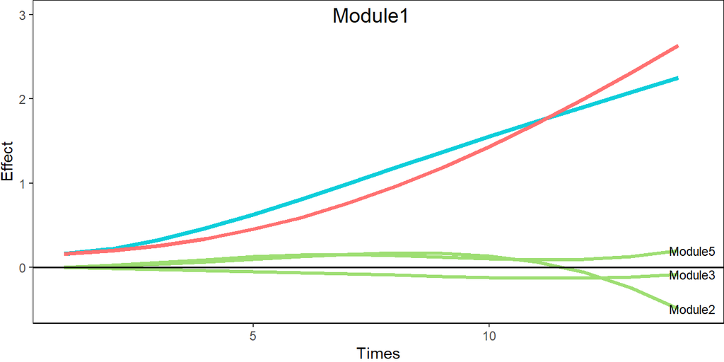

```r
get_decomposition_plot(module_ode1, module_net1, 1)
```

## 5.3 Network visualization between modules

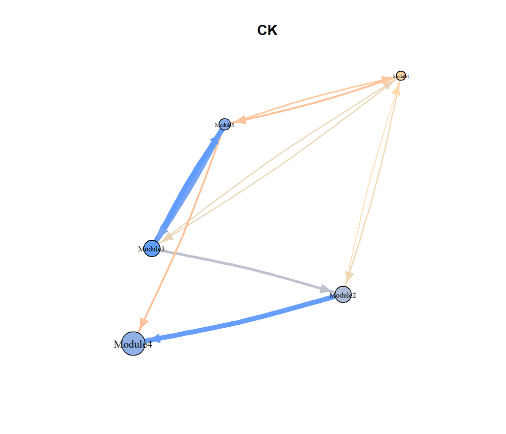

```r
# max_effect control the overall plot colour (eg. ck and stress network)
max_effect <- cbind(get_max_effect(module_net1), get_max_effect(module_net1))

network_plot(k = module_net1, title = "CK", max_effect = max_effect, save_plot = FALSE)
```

## 5.4 Genetic network reconstructed for SNPs

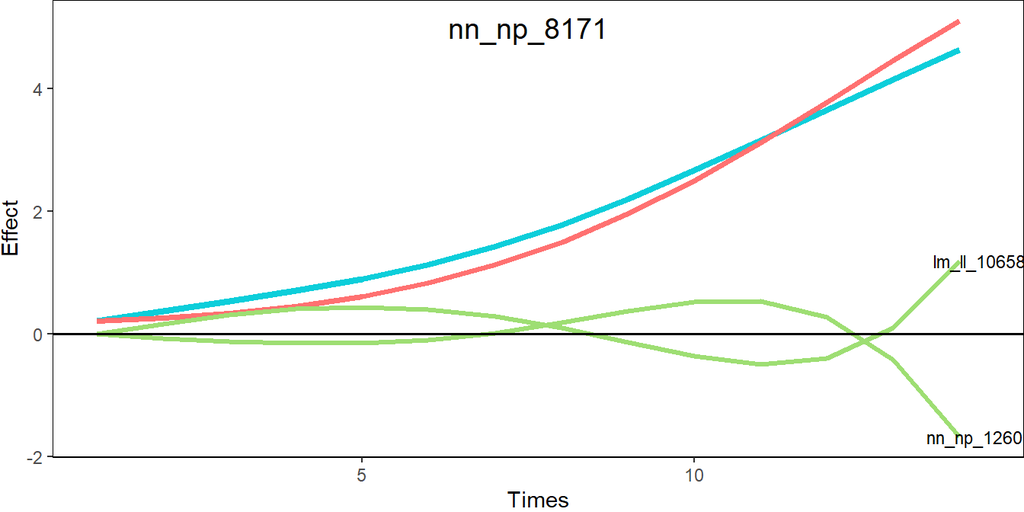

```r
m1_ck <- get_subset_data(data = c1$clustered_data[[1]], cluster = 1)
m1_ck_ode <- get_ode_par(data = m1_ck, times = 1:14, order = 3, reduction = TRUE,
    parallel = TRUE)
## Start variable selection
## Finish variable selection
## Start ODE solving
## Finish ODE solving
m1_ck_net <- get_all_net(m1_ck_ode)
get_decomposition_plot(m1_ck_ode, m1_ck_net, 2)
```

## 5.5 Network visualization between SNPs

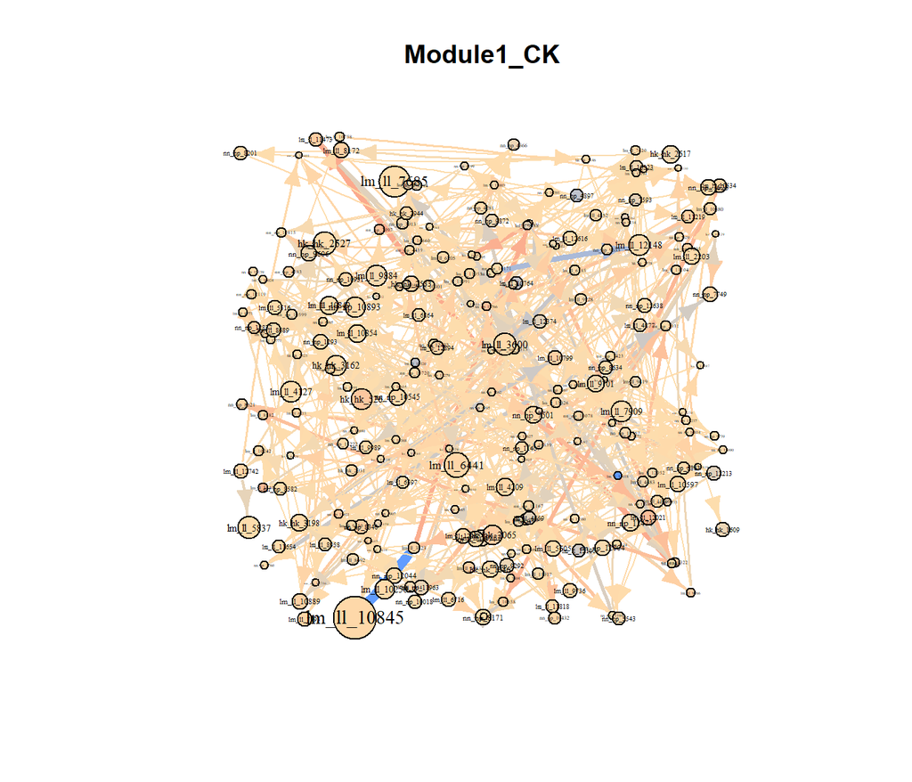

```r
max_effect <- cbind(get_max_effect(m1_ck_net), get_max_effect(m1_ck_net))

network_plot(k = m1_ck_net, title = "Module1_CK", max_effect = max_effect, save_plot = FALSE)
```

## 5.6 Theory behind nLV-based ordinary differential equation (ODE)

Let $\mathbf{g}_{s}^{y}=\left(g_{s}^{y}\left(t_{1}\right), \ldots, g_{s}^{y}\left(t_{T}\right)\right)$ and $\mathbf{g}_{s}^{z}=\left(g_{s}^{z}\left(t_{1}\right), \ldots, g_{s}^{z}\left(t_{T}\right)\right)$ denote two vectors of the overall genetic effect of SNP s on trait development in environments $X$ and $Y$, respectively. According to evolutionary game theory, we decompose the net genetic effect of a SNP into its independent effect component and dependent effect component, which is described by an $n L V$-based ordinary differential equation (ODE), i.e.,
$$g_{s}^{k}(t)=Q_{s}^{k}\left(g_{s}^{k}(t) ; \Theta_{s}^{k}\right)+\sum_{s^{\prime}=1, s^{\prime} \neq s}^{s} Q_{s s^{\prime}}^{k}\left(g_{s^{\prime}}^{k}(t) ; \Theta_{s s^{\prime}}^{k}\right)$$

where $g_{s}^{k}(t)$ is the derivative of the net genetic effect of SNP s on trait development at time $t$ in environment $k, Q_{s}^{k}(\cdot)$ is a time-varying function that characterizes the independent genetic effect of SNP s that occurs when it is assumed to be in isolation, $Q_{s s^{\prime}}^{k}(\cdot)$ is a timevarying function that characterizes the dependent genetic effect of SNP s that arises from the influence of another SNP s’ on it, and $\Theta_{s}^{k}$ and $\Theta_{s s^{\prime}}^{k}$ are a set of parameters that fit the independent and dependent functions, respectively. Since both time-varying independent and dependent effects do not follow an explicit equation, we implement a nonparametric smoothing approach, such as Legendre Orthogonal Polynomials (LOP).

# 6.Multilayer interactome networks Construction

The salient feature of FunGraph is to organize hundreds of thousands or thousands of thousands of SNPs in a GWAS into a multilayer interaction network by classifying these SNPs into distinct modules.

## 6.1 Choose target module to further classify into submodules

```r
table(c1$clustered_data[[1]]$cluster)
```

```
##
##   1   2   3   4   5
## 231 160 142 122 345
```

## 6.2 biFunClu for the target module

Select cluster = 1 in previous results

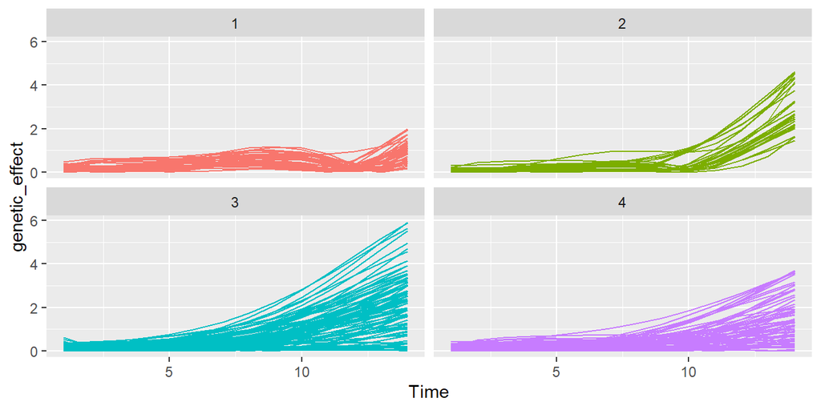

```r
m1 <- cbind(get_subset_data(data = c1$clustered_data[[1]], cluster = 1), get_subset_data(data = c1$clustered_data[[2]],
    cluster = 1))

set.seed(2021)  #use same initial value
input2 <- get_init_par(data = m1, k = 4, legendre_order = 4, times = 1:14)
c2 <- get_cluster(input = input2)
## Start biFunClu Calculation
## Cluster_number=4 Legendre_order=4
## iter= 1 LL= -2990.911
## iter= 2 LL= -3061.977
## iter= 3 LL= -3094.394
## iter= 4 LL= -3114.155
## iter= 5 LL= -3124.941
## iter= 6 LL= -3134.692
## iter= 7 LL= -3140.815
## iter= 8 LL= -3145.529
## iter= 9 LL= -3148.673
## iter= 10 LL= -3151.713
## iter= 11 LL= -3154.353
## iter= 12 LL= -3156.652
## iter= 13 LL= -3159.948
## iter= 14 LL= -3165.309
## iter= 15 LL= -3168.519
## iter= 16 LL= -3170.573
## iter= 17 LL= -3171.719
## iter= 18 LL= -3171.792
## Finish biFunClu Calculationcluster result data written
# view stress data
get_cluster_base_plot(c2$clustered_data[[2]])
```

```r
table(c2$clustered_data[[2]]$cluster)
```

```
##
##  1  2  3  4
## 43 25 94 69
```

## 6.3 Network construction between submodules

For a target module,ODE solving can be easily done similary to section 5

```r
submodule1_data <- get_module_data(data_par = c2$curve_par, times = 1:14)
submodule1_ode1 <- get_ode_par(data = submodule1_data[[1]], times = 1:14, order = 3,
    reduction = FALSE, parallel = TRUE)
## Start variable selection
## Finish variable selection
## Start ODE solving
## Finish ODE solving
submodule1_net1 <- get_all_net(submodule1_ode1)
max_effect1 <- cbind(get_max_effect(submodule1_net1), get_max_effect(submodule1_net1))
```

Network visualization

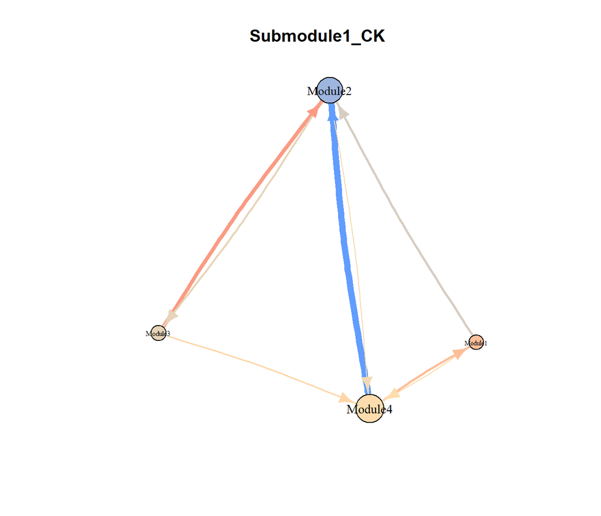

```r
network_plot(k = submodule1_net1, title = "Submodule1_CK", max_effect = max_effect1,
    save_plot = FALSE)
```

## 6.4 Network construction within submodules

Then subnetwork within submodule can be constructed

```r
m1_1_ck <- get_subset_data(data = c2$clustered_data[[1]], cluster = 2)
m1_1_ck_ode <- get_ode_par(data = m1_1_ck, times = 1:14, order = 3, reduction = TRUE,
    parallel = TRUE)
## Start variable selection
## Finish variable selection
## Start ODE solving
## Finish ODE solving
m1_1_ck_net <- get_all_net(m1_1_ck_ode)
max_effect2 <- cbind(get_max_effect(m1_1_ck_net), get_max_effect(m1_1_ck_net))
```

Network visualization

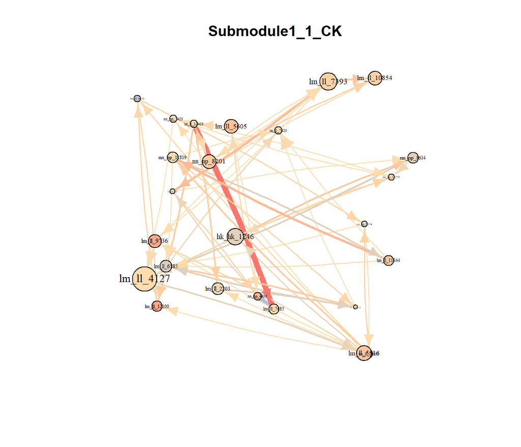

```r
network_plot(k = m1_1_ck_net, title = "Submodule1_1_CK", max_effect = max_effect2,
    save_plot = FALSE)
```

# Troubleshooting

### singular gradient/ initial value in ‘vmmin’ is not finite/ non-finite value supplied by optim.

Potential solution: Usually it was caused by redundant information in dataset, just remove non-numeric content in datasets. Alternatively, column names of input dataset contain underscore, hash, dash and so on may results failure in matching column names in `get_ode_par()` function.  
Another possible solution is to try different value for initial parameters, generally initial parameters for biSAD covariance matrix should between 0.1 to 10, and initial parameters for model logistic growth curve should be 0.1 to maximum observation phenotypic data.

### The calculation took too much time and/or estimated parameters are inaccurate.

Potential solution: Parameters estimation for biFunMap and biFunClu can be improved through the manually given determinant and inverse for biSAD1 covariance matrix than the implanted `solve()` and `det()` functions in R, but it would be challenging and time consuming.

### The optimal number of k is difficult to choose.

Potential solution: The initial parameters were randomly given and may influent the outcome of BIC value depending on the dataset, for a certain k it is recommended to run several times and choose the minimal BIC value as the actual BIC value.

### Calculation stopped when running `get_ode_par()`.

Potential solution: In the rare case that no connection can be found between target module/SNP and the rest dataset, get_interaction function would return with missing values NA. Users can either manually assign a most relevant dataset by `cor()`, or skip this module/SNP

### The intrinsic growth curves of certain genetic effect may not be positive.

Potential solution: Try different ODE initial values in `get_value()` funciton, regularization in estimating ODE parameters by modify ode_optimize function in source R code should also be a potential solution.